# Hackathon Project

2025-02-22

# Introduction

The main goal of a movie poster is to hook an audience into the idea of the movie. It goes without saying then that different genres may have different strategies in grabbing the attention of their corresponding audience. One of the first thing that comes to your attention when you see a poster is the color. Family movies, for example, may frequently use lighter colors or higher RGB values, while horror films may use darker colors as to illicit an eerie feeling from just the poster.

In this project, we are using the posters of the top 1000 rated movies on IMDB, mapping those movies to the respective percentages of each color in that poster. With this information, we can make conclusions about the types of colors that different genres of movies use to attract their audience and perhaps even make some assumptions about why movies chose these colors.

# Background

We collected this data from [Kaggle.com](https://www.kaggle.com/datasets/harshitshankhdhar/imdb-dataset-of-top-1000-movies-and-tv-shows?resource=download) and it was initially compiled straight from the IMDB database 4 years ago.

From this dataset, we will be using the following variables:

- **Genre**: A list of Genres that corresponds to each movie. We will mutate this to only include the first genre, being the strongest corresponding genre
- **Poster_Link**: Link to a jpeg file of the poster of the corresponding movie. We used this to create a program returning the percentages of each color used in the poster
- **IMDB_Rating**: Rating on IMDB out of ten to compare to the shade to test a later hypothesis

From this dataset, we created the following variable:

- **Colors (**Red, Green, Blue, Maroon, Pink, Brown, Orange, Apricot, Olive, Yellow, Beige, Lime, Mint, Teal, Cyan, Navy, Purple, Lavender, Magenta, Black, Grey, White): A list of each color we are testing with the value corresponding to the percent of that color found in that poster

# Mapping Color from JPEG

Each movie in our data set had a URL that let to a JPEG of its poster. Our first job was to get useful information out of these JPEGs so we had a good set of data for our analysis. We took the following steps to get the color data from each poster:

1. Scraped the contents of each webpage
2. Converted each JPEG to the PPM format, a much more readily parsed image format
3. Converted each PPM to a simple BitMap we made, that housed a table of pixels
4. Creating a set of 22 simple, distinct, and representative colors of the movie posters
5. Simplified each BitMap by classifying each pixel into one of the simple colors in our set by using the Euclidean distance between each pixel and each simple color, and setting each pixel to its closest match
6. Finding the percentages of each simple color in each movie poster and exporting it in a CSV

# Visualization

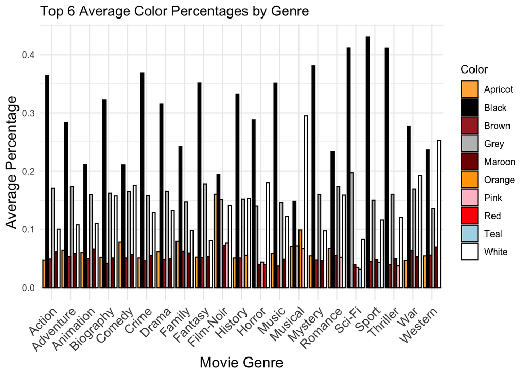

```r
# Calculate the mean percentage for each color and genre
color_means <- long_data %>%
  group_by(Genre, Color) %>%
  summarize(mean_percentage = mean(Percentage), .groups = "drop") %>%
  filter(Color != "Shade")

# Select the top 4 colors with the highest percentage for each genre
top_colors_per_genre <- color_means %>%
  group_by(Genre) %>%
  slice_max(order_by = mean_percentage, n = 6) %>%
  ungroup()

# Define a color mapping for each color name
color_mapping <- c(
  "Red" = "red", "Green" = "green", "Blue" = "blue", "Maroon" = "#800000",
  "Pink" = "pink", "Brown" = "#A52A2A", "Orange" = "orange", "Apricot" = "#FFB347",
  "Olive" = "#808000", "Yellow" = "yellow", "Beige" = "#F5F5DC", "Lime" = "green",
  "Mint" = "#98FF98", "Teal" = "lightblue", "Cyan" = "cyan", "Navy" = "navy",
  "Purple" = "purple", "Lavender" = "#E6E6FA", "Magenta" = "magenta",
  "Black" = "black", "Grey" = "grey", "White" = "white"
)

# Create a grouped bar chart with actual colors
ggplot(top_colors_per_genre, aes(x = Genre, y = mean_percentage, fill = Color)) +
  geom_bar(stat = "identity", position = "dodge", color = "black") +  # Adds black borders for better visibility
  scale_fill_manual(values = color_mapping) +  # Apply color mapping
  theme_minimal() +
  theme(axis.text.x = element_text(angle = 45, hjust = 1, size = 12),
        axis.title = element_text(size = 14),
        legend.position = "right") +
  labs(title = "Top 6 Average Color Percentages by Genre",
       x = "Movie Genre",
       y = "Average Percentage",
       fill = "Color")
```

```r
grouped_movies
```

```
## # A tibble: 21 × 23
##    Genre         Red   Green    Blue Maroon   Pink  Brown  Orange Apricot  Olive
##    <chr>       <dbl>   <dbl>   <dbl>  <dbl>  <dbl>  <dbl>   <dbl>   <dbl>  <dbl>
##  1 Action    0.0109  1.16e-3 0.00558 0.0618 0.0321 0.0492 0.0166   0.0471 0.0126
##  2 Adventure 0.00702 2.51e-3 0.0165  0.0589 0.0316 0.0533 0.0259   0.0638 0.0150
##  3 Animation 0.00723 1.04e-2 0.0411  0.0657 0.0266 0.0499 0.0200   0.0601 0.0188
##  4 Biography 0.00643 1.62e-3 0.00738 0.0510 0.0400 0.0416 0.0291   0.0521 0.0131
##  5 Comedy    0.00986 2.95e-3 0.0114  0.0573 0.0465 0.0510 0.0191   0.0781 0.0140
##  6 Crime     0.0121  5.58e-4 0.00439 0.0554 0.0430 0.0459 0.0152   0.0510 0.0133
##  7 Drama     0.0102  1.04e-3 0.00775 0.0504 0.0417 0.0484 0.0240   0.0618 0.0154
##  8 Family    0.00639 1.21e-2 0.0260  0.0595 0.0258 0.0620 0.0303   0.0796 0.0170
##  9 Fantasy   0.00165 4.81e-3 0.0155  0.0533 0.0388 0.0518 0.00935  0.0524 0.0135
## 10 Film-Noir 0.00218 2.03e-4 0.00107 0.0725 0.0764 0.0585 0.0301   0.160  0.0167
## # ℹ 11 more rows
## # ℹ 13 more variables: Yellow <dbl>, Beige <dbl>, Lime <dbl>, Mint <dbl>,
## #   Teal <dbl>, Cyan <dbl>, Navy <dbl>, Purple <dbl>, Lavender <dbl>,
## #   Magenta <dbl>, Black <dbl>, Grey <dbl>, White <dbl>
```

# Hypothesis Testing

## Question: Is there a correlation between the percent of red in a poster and the genre that the movie is in?

$$H_0: \mu_{\text{Drama}} = \mu_{\text{Comedy}} \text{ ... } = \mu_{k} \\
H_{\alpha} = \text{at least 1 } \mu_{i} \neq \mu_{j} \text{ for all i,
j}$$

## Set the Significance Level

### $0.05$

## ANOVA Testing

### **Total Sum of Squares: SST**

Total variation in the dataset

$$SST = \sum_{i=1}^{n} (Y_i - \overline{Y})^2 \\
Y_i = \text{each individual obervation in the sample} \\
\overline{Y} = \text{the mean of observations in the entire dataset}$$

### **Sum of Squares Between Groups: SSB**

Variation between genre mean and total dataset mean

$$SSB = \sum_{j=1}^{k} n_j (\overline{Y}_j - \overline{Y})^2 \\
n_j = \text{number of observations in genre } j \\
\overline{Y_j} = \text{mean observations in a genre } j \\
\overline{Y} = \text{mean of obervations in the entire dataset}$$

### **Sum of Squares Within Groups: SSW**

Variation within each group

$$SSW = \sum_{j=1}^{k} \sum_{i=1}^{n_j} (Y_{ij} - \overline{Y}_j)^2 \\
Y_{ij} = \text{each obervation within a group } j \\
\overline{Y_j} = \text{mean of obervations within a group}$$

### **Mean Square Between Each Group: MSB**

Mean of squares divided by degrees of freedom for f-distribution

$$MSB = \frac{SSB}{k -1} \\
k = \text{number of genres}$$

### **Mean Square Within Each Group: MSW**

$$MSW = \frac{SSW}{n - k} \\
n - k = \text{number of movies - number of genres}$$

### **F-Statistic**

$$\frac{MSB}{MSW}$$

### **P-Value**:

Calculate the likelihood of obtaining a result equal to or less likely than the F-Stat calculated under the F-Distribution

```r
grouped_movies
```

```
## # A tibble: 21 × 23
##    Genre         Red   Green    Blue Maroon   Pink  Brown  Orange Apricot  Olive
##    <chr>       <dbl>   <dbl>   <dbl>  <dbl>  <dbl>  <dbl>   <dbl>   <dbl>  <dbl>
##  1 Action    0.0109  1.16e-3 0.00558 0.0618 0.0321 0.0492 0.0166   0.0471 0.0126
##  2 Adventure 0.00702 2.51e-3 0.0165  0.0589 0.0316 0.0533 0.0259   0.0638 0.0150
##  3 Animation 0.00723 1.04e-2 0.0411  0.0657 0.0266 0.0499 0.0200   0.0601 0.0188
##  4 Biography 0.00643 1.62e-3 0.00738 0.0510 0.0400 0.0416 0.0291   0.0521 0.0131
##  5 Comedy    0.00986 2.95e-3 0.0114  0.0573 0.0465 0.0510 0.0191   0.0781 0.0140
##  6 Crime     0.0121  5.58e-4 0.00439 0.0554 0.0430 0.0459 0.0152   0.0510 0.0133
##  7 Drama     0.0102  1.04e-3 0.00775 0.0504 0.0417 0.0484 0.0240   0.0618 0.0154
##  8 Family    0.00639 1.21e-2 0.0260  0.0595 0.0258 0.0620 0.0303   0.0796 0.0170
##  9 Fantasy   0.00165 4.81e-3 0.0155  0.0533 0.0388 0.0518 0.00935  0.0524 0.0135
## 10 Film-Noir 0.00218 2.03e-4 0.00107 0.0725 0.0764 0.0585 0.0301   0.160  0.0167
## # ℹ 11 more rows
## # ℹ 13 more variables: Yellow <dbl>, Beige <dbl>, Lime <dbl>, Mint <dbl>,
## #   Teal <dbl>, Cyan <dbl>, Navy <dbl>, Purple <dbl>, Lavender <dbl>,
## #   Magenta <dbl>, Black <dbl>, Grey <dbl>, White <dbl>
```

```r
significant_data <- grouped_movies %>% drop_na() %>%
  select(Genre, Red, Maroon, Orange, Brown, Apricot, Beige, Mint, Purple, Magenta, Black, White, Cyan, Navy, Pink, Grey, Olive, Lime)


long_significant_data <- pivot_longer(significant_data, cols = -Genre, names_to = "Color", values_to = "Percentage")


top_genres <- long_significant_data %>%
  group_by(Color, Genre) %>%
  summarize(mean_percentage = mean(Percentage), .groups = "drop") %>%
  arrange(Color, desc(mean_percentage)) %>%
  group_by(Color)


top_genres
```

```
## # A tibble: 357 × 3
## # Groups:   Color [17]
##    Color   Genre     mean_percentage
##    <chr>   <chr>               <dbl>
##  1 Apricot Film-Noir          0.160
##  2 Apricot Family             0.0796
##  3 Apricot Comedy             0.0781
##  4 Apricot Musical            0.0703
##  5 Apricot Romance            0.0670
##  6 Apricot Adventure          0.0638
##  7 Apricot Drama              0.0618
##  8 Apricot Animation          0.0601
##  9 Apricot Music              0.0588
## 10 Apricot Mystery            0.0547
## # ℹ 347 more rows
```

```r
significant_data
```

```
## # A tibble: 21 × 18
##    Genre        Red Maroon  Orange  Brown Apricot  Beige    Mint  Purple Magenta
##    <chr>      <dbl>  <dbl>   <dbl>  <dbl>   <dbl>  <dbl>   <dbl>   <dbl>   <dbl>
##  1 Action   0.0109  0.0618 0.0166  0.0492  0.0471 0.0265 0.0196  1.02e-3 2.25e-4
##  2 Adventu… 0.00702 0.0589 0.0259  0.0533  0.0638 0.0302 0.0250  1.26e-3 1.66e-4
##  3 Animati… 0.00723 0.0657 0.0200  0.0499  0.0601 0.0338 0.0358  1.01e-3 9.55e-5
##  4 Biograp… 0.00643 0.0510 0.0291  0.0416  0.0521 0.0386 0.0214  3.80e-3 6.50e-4
##  5 Comedy   0.00986 0.0573 0.0191  0.0510  0.0781 0.0440 0.0200  1.06e-3 4.75e-5
##  6 Crime    0.0121  0.0554 0.0152  0.0459  0.0510 0.0234 0.0142  1.07e-4 7.11e-5
##  7 Drama    0.0102  0.0504 0.0240  0.0484  0.0618 0.0336 0.0161  1.23e-3 1.66e-4
##  8 Family   0.00639 0.0595 0.0303  0.0620  0.0796 0.0433 0.0242  2.86e-4 7.43e-6
##  9 Fantasy  0.00165 0.0533 0.00935 0.0518  0.0524 0.0286 0.0161  1.17e-5 0
## 10 Film-No… 0.00218 0.0725 0.0301  0.0585  0.160  0.0525 0.00787 0       5.08e-5
## # ℹ 11 more rows
## # ℹ 8 more variables: Black <dbl>, White <dbl>, Cyan <dbl>, Navy <dbl>,
## #   Pink <dbl>, Grey <dbl>, Olive <dbl>, Lime <dbl>
```

- Red
- Maroon
- Brown
- Orange
- Apricot
- Beige
- Mint
- Purple
- Black
- White

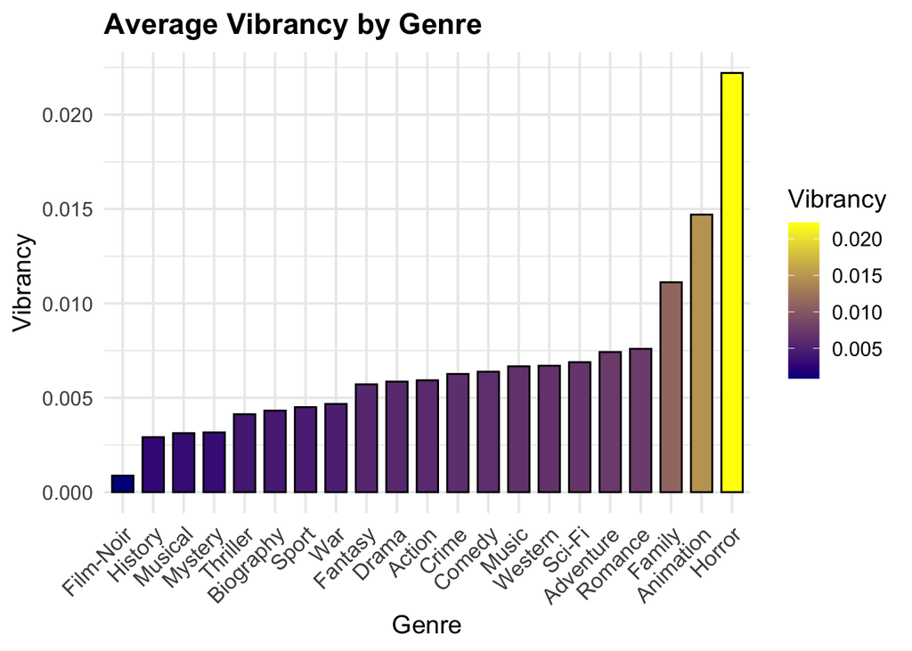

```r
lighter_color_data = new_movies %>%
  group_by(Genre) %>%
  summarize(
    avg_red = mean(Red),
    avg_yellow = mean(Yellow),
    avg_green = mean(Green),
    avg_blue = mean(Blue)
  ) %>%
  mutate(avg_bright = (avg_red + avg_yellow + avg_blue + avg_green) / 4) %>%
  arrange(desc(avg_bright))


ggplot(lighter_color_data, aes(x = reorder(Genre, avg_bright), y = avg_bright, fill = avg_bright)) +
  geom_col(color = "black", width = 0.7) +
  scale_fill_gradient(low = "darkblue", high = "yellow") +
  theme_minimal(base_size = 14) +
  labs(
    title = "Average Vibrancy by Genre",
    x = "Genre",
    y = "Vibrancy",
    fill = "Vibrancy"
  ) +
  theme(
    axis.text.x = element_text(angle = 45, hjust = 1, size = 12),
    axis.title = element_text(size = 14),
    plot.title = element_text(size = 16, face = "bold"),
    legend.position = "right"
  )
```

```r
lighter_color_data
```

```
## # A tibble: 21 × 6
##    Genre     avg_red avg_yellow avg_green avg_blue avg_bright
##    <chr>       <dbl>      <dbl>     <dbl>    <dbl>      <dbl>
##  1 Horror    0.0395  0.0384     0.00122    0.00971    0.0222
##  2 Animation 0.00723 0.0000981  0.0104     0.0411     0.0147
##  3 Family    0.00639 0.00000743 0.0121     0.0260     0.0111
##  4 Romance   0.0170  0.00115    0.00203    0.0102     0.00759
##  5 Adventure 0.00702 0.00367    0.00251    0.0165     0.00742
##  6 Sci-Fi    0.0236  0.000683   0.0000959  0.00320    0.00689
##  7 Western   0.00685 0.0141     0          0.00585    0.00670
##  8 Music     0.00733 0.00370    0.000713   0.0149     0.00667
##  9 Comedy    0.00986 0.00133    0.00295    0.0114     0.00638
## 10 Crime     0.0121  0.00802    0.000558   0.00439    0.00626
## # ℹ 11 more rows
```

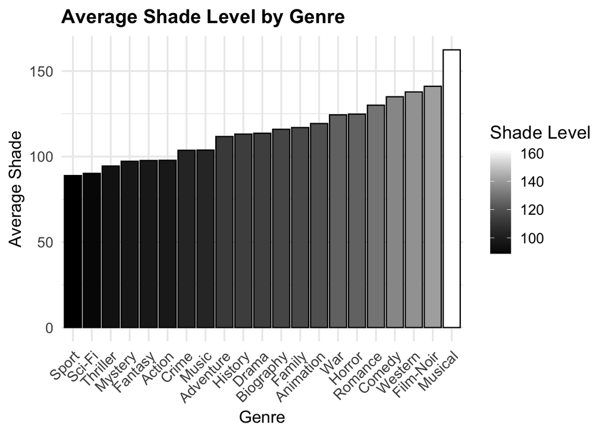

```r
grouped_by_shade = new_movies %>%
  group_by(Genre) %>%
  summarize(avg_shade = mean(Shade, na.rm = TRUE))  # Ensure NA values don't cause issues

ggplot(grouped_by_shade, aes(x = reorder(Genre, avg_shade), y = avg_shade, fill = avg_shade)) +
  geom_col(color = "black") +  # Add black borders for better visibility
  scale_fill_gradient(low = "black", high = "white") +  # Shade gradient (lighter to darker)
  theme_minimal(base_size = 15) +  # Clean theme with readable font size
  labs(title = "Average Shade Level by Genre",
       x = "Genre",
       y = "Average Shade",
       fill = "Shade Level") +
  theme(axis.text.x = element_text(angle = 45, hjust = 1),  # Tilt labels for readability
        axis.title = element_text(size = 14),
        plot.title = element_text(size = 16, face = "bold"))
```

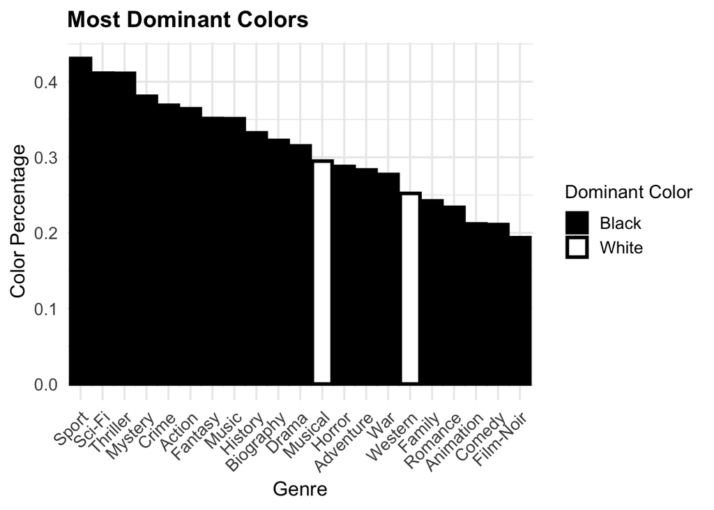

```r
dominant_colors <- top_genres %>%
  group_by(Genre) %>%
  slice_max(order_by = mean_percentage, n = 1) %>%
  ungroup()


color_map <- c("Red" = "red", "Green" = "green", "Blue" = "blue", "Yellow" = "yellow",
               "Orange" = "orange", "Pink" = "pink", "Purple" = "purple", "Cyan" = "#00FFFF",
               "Navy" = "navy", "Black" = "black", "White" = "white", "Grey" = "grey",
               "Magenta" = "purple", "Beige" = "#F5F5DC", "Lime" = "lightgreen",
               "Teal" = "lightblue", "Brown" = "#A52A2A", "Apricot" = "#FFB347",
               "Olive" = "#808000", "Lavender" = "#E6E6FA", "Mint" = "#98FF98", "Maroon" = "darkred")


ggplot(dominant_colors, aes(x = reorder(Genre, -mean_percentage), y = mean_percentage, fill = Color)) +
  geom_bar(stat = "identity", color = "black", size = 1.2) +
  scale_fill_manual(values = color_map) +
  theme_minimal(base_size = 15) +
  labs(title = "Most Dominant Colors",
       x = "Genre",
       y = "Color Percentage",
       fill = "Dominant Color") +
  theme(axis.text.x = element_text(angle = 45, hjust = 1, vjust = 1),
        axis.title = element_text(size = 14),
        plot.title = element_text(size = 16, face = "bold"),
        legend.title = element_text(size = 13),
        legend.text = element_text(size = 12))
```

```r
top_genres
```

```
## # A tibble: 357 × 3
## # Groups:   Color [17]
##    Color   Genre     mean_percentage
##    <chr>   <chr>               <dbl>
##  1 Apricot Film-Noir          0.160
##  2 Apricot Family             0.0796
##  3 Apricot Comedy             0.0781
##  4 Apricot Musical            0.0703
##  5 Apricot Romance            0.0670
##  6 Apricot Adventure          0.0638
##  7 Apricot Drama              0.0618
##  8 Apricot Animation          0.0601
##  9 Apricot Music              0.0588
## 10 Apricot Mystery            0.0547
## # ℹ 347 more rows
```

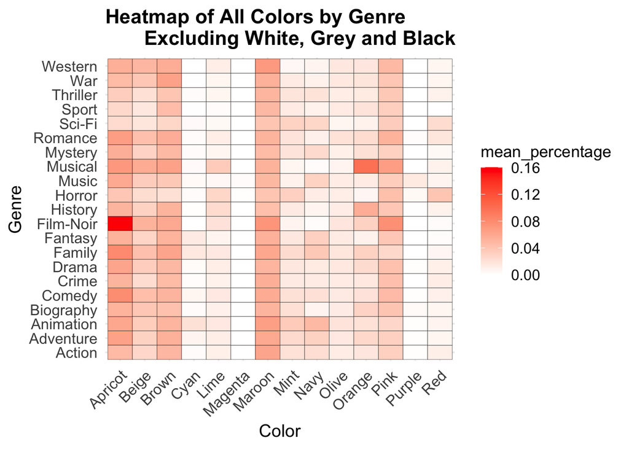

```r
color_mapping <- c("avg_red" = "red", "avg_green" = "green", "avg_blue" = "blue")


ggplot(top_genres %>% filter(Color != "Black" & Color != "White" & Color != "Grey"), aes(x = Color, y = Genre, fill = mean_percentage)) +
  geom_tile(color = "black", size = 0.1) +
  scale_fill_gradient(low = "white", high = "red") +
  labs(title = "Heatmap of All Colors by Genre
       Excluding White, Grey and Black",
       x = "Color",
       y = "Genre") +
  theme_minimal(base_size = 14) +
  theme(axis.text.x = element_text(angle = 45, hjust = 1),
        axis.text = element_text(size = 12),
        axis.title = element_text(size = 14),
        plot.title = element_text(size = 16, face = "bold"),
        legend.title = element_text(size = 13),
        legend.text = element_text(size = 12))
```

```python
import pandas as pd
import matplotlib.pyplot as plt

raw_imdb_movies = pd.read_csv("~/Desktop/Hackathon-Project2025/newCSV.csv")

imdb_movies = raw_imdb_movies[["Series_Title", "Genre", "Red", "Green", "Blue", "Maroon", "Pink", "Brown", "Orange", "Apricot", "Olive", "Yellow", "Beige", "Lime", "Mint", "Teal", "Cyan", "Navy", "Purple", "Lavender", "Magenta", "Black", "Grey", "White"]]

imdb_movies.loc[:, "Genre"] = imdb_movies["Genre"].str.split(",").str[0]

imdb_movies
```

```
##                  Series_Title   Genre       Red  ...     Black      Grey     White
## 0    The Shawshank Redemption   Drama  0.000000  ...  0.557569  0.056046  0.010661
## 1               The Godfather   Crime  0.000000  ...  0.689918  0.067469  0.018885
## 2             The Dark Knight  Action  0.000457  ...  0.382272  0.188547  0.019799
## 3      The Godfather: Part II   Crime  0.000000  ...  0.860798  0.051630  0.003351
## 4                12 Angry Men   Crime  0.000000  ...  0.083460  0.035486  0.124581
## ..                        ...     ...       ...  ...       ...       ...       ...
## 995    Breakfast at Tiffany's  Comedy  0.021170  ...  0.082242  0.071885  0.468322
## 996                     Giant   Drama  0.000000  ...  0.042339  0.045233  0.426287
## 997     From Here to Eternity   Drama  0.000000  ...  0.042644  0.119708  0.261499
## 998                  Lifeboat   Drama  0.000000  ...  0.195248  0.151843  0.264088
## 999              The 39 Steps   Crime  0.000000  ...  0.080871  0.069144  0.032288
##
## [1000 rows x 24 columns]
```

```python
dark_knight = imdb_movies[imdb_movies["Series_Title"] == "The Dark Knight"].iloc[:, 2:]

dark_knight
```

```
##         Red  Green  Blue    Maroon  ...  Magenta     Black      Grey     White
## 2  0.000457    0.0   0.0  0.022083  ...      0.0  0.382272  0.188547  0.019799
##
## [1 rows x 22 columns]
```

```python
colors = dark_knight.columns
colors
```

```
## Index(['Red', 'Green', 'Blue', 'Maroon', 'Pink', 'Brown', 'Orange', 'Apricot',
##        'Olive', 'Yellow', 'Beige', 'Lime', 'Mint', 'Teal', 'Cyan', 'Navy',
##        'Purple', 'Lavender', 'Magenta', 'Black', 'Grey', 'White'],
##       dtype='object')
```

```python
percentages = dark_knight.values.flatten()


color_map = {
    "Red": "red", "Green": "green", "Blue": "blue", "Yellow": "yellow",
    "Orange": "orange", "Pink": "pink", "Purple": "purple", "Cyan": "#00FFFF",
    "Navy": "navy", "Black": "black", "White": "white", "Grey": "grey",
    "Magenta": "purple", "Beige": "#F5F5DC", "Lime": "lightgreen",
    "Teal": "lightblue", "Brown": "#A52A2A", "Apricot": "#FFB347",
    "Olive": "#808000", "Lavender": "#E6E6FA", "Mint": "#98FF98"
}


color_values = [color_map.get(c) for c in colors]


plt.figure(figsize=(8, 8))


plt.pie(percentages,colors=color_values, startangle=140, textprops={'fontsize': 12, 'color': 'black'}, wedgeprops={'edgecolor': 'black'})
```

```
## ([<matplotlib.patches.Wedge object at 0x115bdb6a0>, <matplotlib.patches.Wedge object at 0x115bdb5e0>, <matplotlib.patches.Wedge object at 0x115c8c130>, <matplotlib.patches.Wedge object at 0x115c8c670>, <matplotlib.patches.Wedge object at 0x115c8cbb0>, <matplotlib.patches.Wedge object at 0x115c8d0…
```

```python
plt.title("Color Distribution in The Dark Knight's Poster", fontsize=16)
plt.axis('equal')
```

```
## (np.float64(-1.0999999433942511), np.float64(1.099999637512985), np.float64(-1.0999998382020648), np.float64(1.0999973929158344))
```

[figure not shown]

```python
plt.show()
```

Compared to actual The Dark Knight poster:

[figure not shown]

```python
gwh = imdb_movies[imdb_movies["Series_Title"] == "Avatar"].iloc[:, 2:]

dark_knight
```

```
##         Red  Green  Blue    Maroon  ...  Magenta     Black      Grey     White
## 2  0.000457    0.0   0.0  0.022083  ...      0.0  0.382272  0.188547  0.019799
##
## [1 rows x 22 columns]
```

```python
# Extract color names and their corresponding values
colors = gwh.columns
colors
```

```
## Index(['Red', 'Green', 'Blue', 'Maroon', 'Pink', 'Brown', 'Orange', 'Apricot',
##        'Olive', 'Yellow', 'Beige', 'Lime', 'Mint', 'Teal', 'Cyan', 'Navy',
##        'Purple', 'Lavender', 'Magenta', 'Black', 'Grey', 'White'],
##       dtype='object')
```

```python
percentages = gwh.values.flatten()

# Define actual color codes for better visualization
color_map = {
    "Red": "red", "Green": "green", "Blue": "blue", "Yellow": "yellow",
    "Orange": "orange", "Pink": "pink", "Purple": "purple", "Cyan": "#00FFFF",
    "Navy": "navy", "Black": "black", "White": "white", "Grey": "grey",
    "Magenta": "purple", "Beige": "#F5F5DC", "Lime": "lightgreen",
    "Teal": "lightblue", "Brown": "#A52A2A", "Apricot": "#FFB347",
    "Olive": "#808000", "Lavender": "#E6E6FA", "Mint": "#98FF98", "Maroon": "darkred"
}

# Assign matching colors (fallback to gray if missing)
color_values = [color_map.get(c) for c in colors]

# Plot the pie chart
plt.figure(figsize=(8, 8))

# Make the pie chart more readable
plt.pie(percentages, colors=color_values, startangle=140, textprops={'fontsize': 12, 'color': 'black'}, wedgeprops={'edgecolor': 'black'})
```

```
## ([<matplotlib.patches.Wedge object at 0x115d5c2e0>, <matplotlib.patches.Wedge object at 0x115d5d210>, <matplotlib.patches.Wedge object at 0x115d5ed10>, <matplotlib.patches.Wedge object at 0x115d5f250>, <matplotlib.patches.Wedge object at 0x115d5f790>, <matplotlib.patches.Wedge object at 0x115d5fc…
```

```python
# Title and customizations
plt.title("Color Distribution in Avatar's Poster", fontsize=16)
plt.axis('equal')
```

```
## (np.float64(-1.0999999721807294), np.float64(1.0999992640404477), np.float64(-1.0999998448798982), np.float64(1.0999998414661076))
```

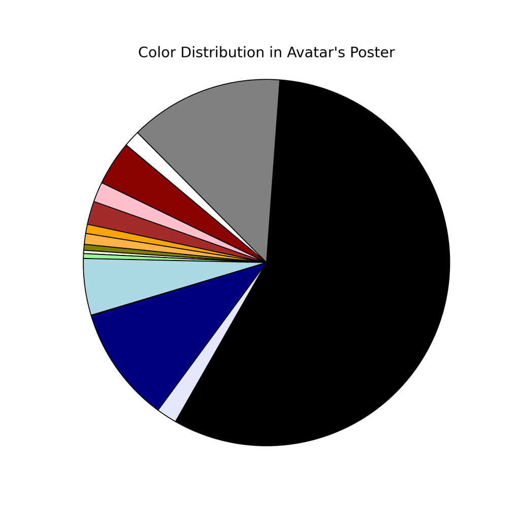

```python
plt.show()
```

# Refrences

OpenAI. ChatGPT (Feb 2025 Version). OpenAI, 2025, https://openai.com/chatgpt. - Used to clean up code and make cleaner graphs